# CV-PR-3

## Task 1: Environment Setup, Image I/O & Morphological Operations

### 1.1 — Environment setup & image loading

```
open cv version:- 5.0.0
gray shape (512, 512) dtype uint8
color shape (512, 512, 3) dtype uint8
```

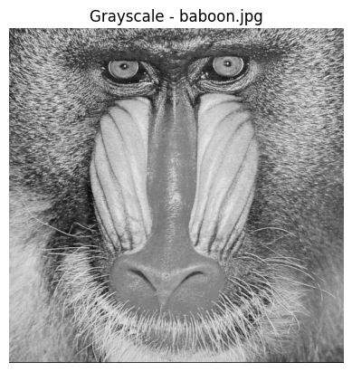

[figure not shown]

### 1.2 Binarize a test image

```
Threshold used: 127.0
```

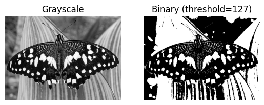

### 1.3 Apply the four morphological operations

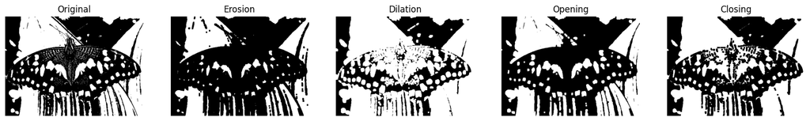

### 1.4 — Kernel shape & size comparison

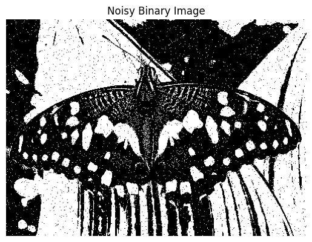

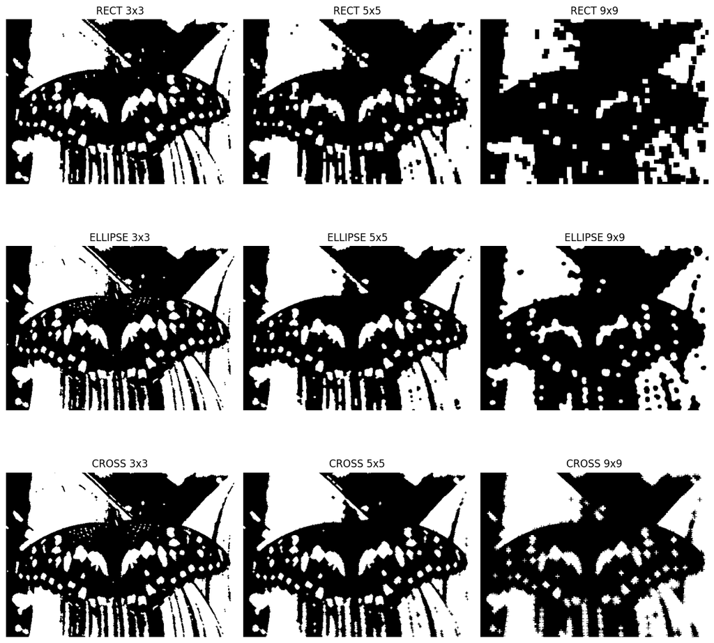

### 1.5 Why morphology works

Erosion is a local **minimum** filter — it shrinks white regions and removes small bright noise specks. Dilation is a local **maximum** filter — it grows white regions and fills small dark gaps.

**Opening** (erode -> dilate) removes small noise while preserving the overall shape and size of larger objects. **Closing** (dilate -> erode) fills small holes/gaps without shrinking the object.

**Real scenario:** before feeding a binary mask into a downstream detector, use **opening** to strip salt-and-pepper camera noise from a background-subtraction mask, and **closing** to seal small gaps in a person's silhouette so the detector gets one solid blob instead of a fragmented one.

## Task 2: Bitwise Operations & Image Histograms

### 2.1 Bitwise AND / OR / XOR / NOT

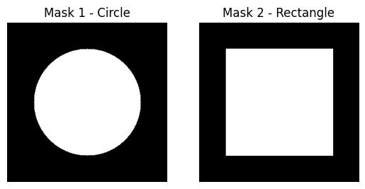

bitwise_and — pixel is white only where both masks are white (the overlap area). bitwise_or — pixel is white where either mask is white (combined area). bitwise_xor — pixel is white where exactly one mask is white, not both (the non-overlapping parts). bitwise_not — flips every pixel: white becomes black, black becomes white. Only needs one input.

[figure not shown]

### 2.2 Applied use-case: masked overlay

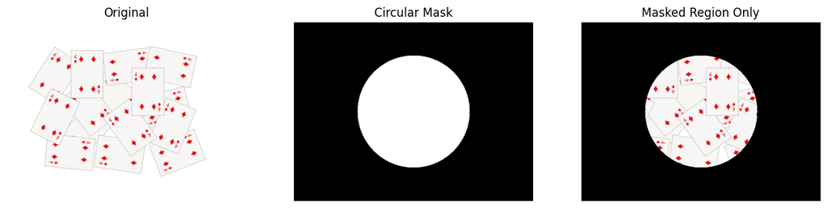

### 2.3 Grayscale & per-channel colour histograms

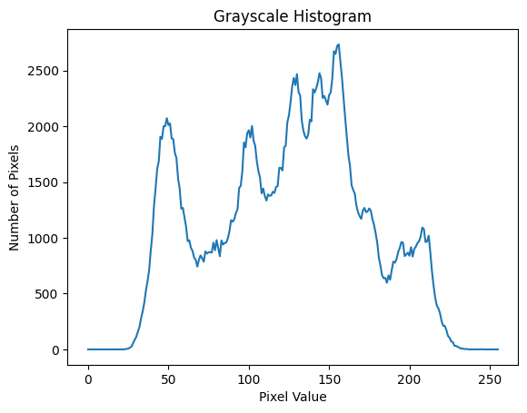

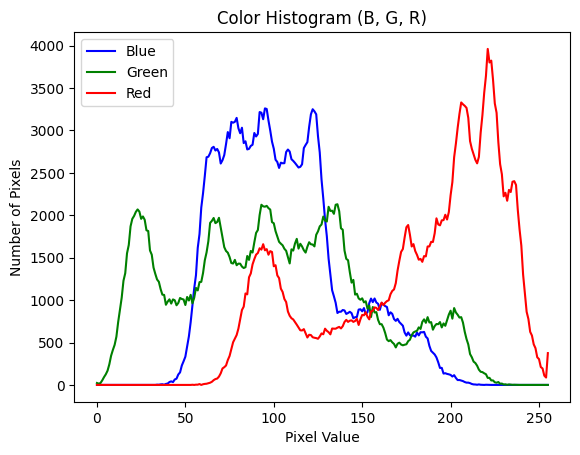

### 2.4 Brightness & contrast adjustment

[figure not shown]

### 2.5 Why alpha/beta and histograms matter

The formula `new_pixel = alpha * pixel + beta` controls two separate things: **alpha** (contrast gain) stretches or compresses how spread out the histogram is around its mean, while **beta** (brightness offset) shifts the whole histogram left or right without changing its spread.

A narrow, tightly clustered histogram means low contrast (the image looks washed out/flat). A histogram that is clipped/piled up at 0 or 255 means the image is over- or under-exposed and has lost detail in that range.

This diagnostic view is useful before running the face and object detectors in later tasks — if a real camera frame's histogram is too dark or too narrow, you know to pre-process it (adjust alpha/beta) before feeding it to the detector, rather than expecting the detector to compensate on its own.

## Task 3: Face Detection with YuNet (OpenCV 5.0)

### 3.1 Load the YuNet face detector

```
Image size used: 3024 x 4032
```

### 3.2 Detect on static images

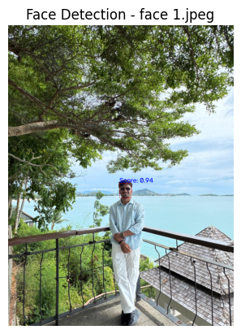

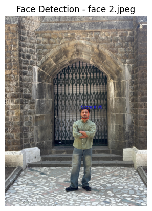

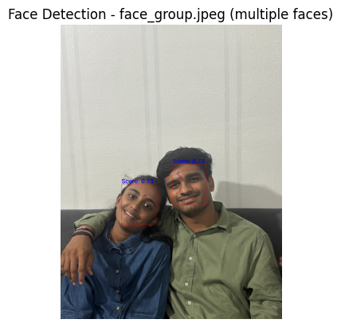

### 3.3 Real-time detection on webcam

```
Frames processed: 801
Total time (seconds): 33.214661598205566
Average FPS: 24.115856114676607
```

### 3.4 Score-threshold experiment & applied privacy use-case

```
Threshold: 0.5 -> Faces detected: 1
Threshold: 0.7 -> Faces detected: 1
Threshold: 0.9 -> Faces detected: 1
```

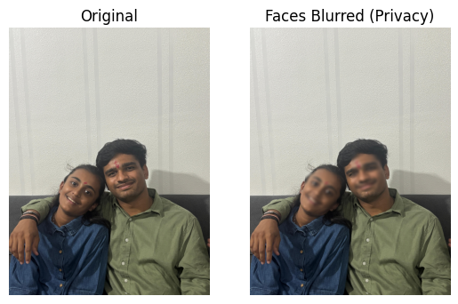

### 3.5 Why YuNet

YuNet is a compact, modern CNN-based face detector — the default detector shipped with OpenCV 5.0 via cv2.FaceDetectorYN. It's trained on diverse, in-the-wild faces, which gives it strong generalization to profile views, partial occlusion (like sunglasses), and small or blurry faces. It also returns 5-point facial landmarks in a single forward pass, unlike older detectors (like Haar cascades) that only give a bounding box.

The score_threshold controls a trade-off: a low threshold catches more real faces but also more false positives (non-faces mistakenly flagged); a high threshold is stricter and misses more borderline-confidence real faces.

For a real-time security camera, a lower threshold (e.g. 0.5-0.7) is usually preferred since missing a real face is worse than a few false alarms. For an offline photo-tagging tool, a higher threshold (e.g. 0.9) is preferred since false-positive tags are more annoying to a user than an occasional missed face they can just tag manually.

## Task 4: Object Detection with YOLO

### 4.1 Load pretrained YOLOv8 & run on static images

[output not shown]

```
image 1/1 d:\deep learning\PR-3\data\images\messi5.jpg: 416x640 8 persons, 1 sports ball, 8.2ms
Speed: 118.9ms preprocess, 8.2ms inference, 42.6ms postprocess per image at shape (1, 3, 416, 640)
```

[figure not shown]

```
image 1/1 d:\deep learning\PR-3\data\images\home.jpg: 480x640 7 kites, 80.5ms
Speed: 967.2ms preprocess, 80.5ms inference, 2.1ms postprocess per image at shape (1, 3, 480, 640)
```

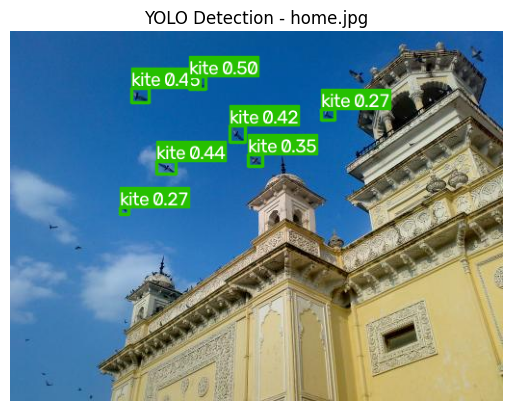

```
image 1/1 d:\deep learning\PR-3\data\images\leuvenA.jpg: 480x640 1 clock, 50.1ms
Speed: 970.8ms preprocess, 50.1ms inference, 34.6ms postprocess per image at shape (1, 3, 480, 640)
```

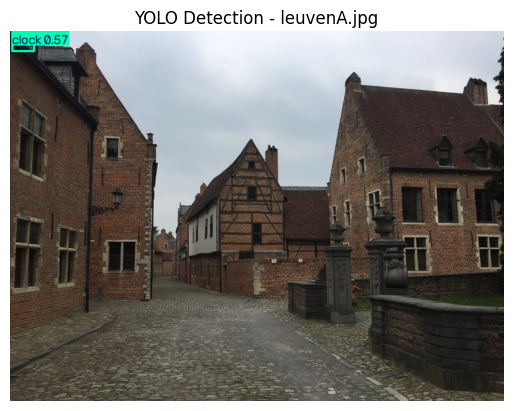

### 4.2 Real-time YOLO on webcam

```
Frames processed: 1393
Total time (seconds): 46.90100312232971
Average FPS: 29.700857279463783
```

### 4.3 Confidence & IoU threshold tuning

```
image 1/1 d:\deep learning\PR-3\data\images\messi5.jpg: 416x640 8 persons, 1 sports ball, 44.6ms
Speed: 994.0ms preprocess, 44.6ms inference, 2.2ms postprocess per image at shape (1, 3, 416, 640)
Confidence: 0.25 -> Boxes kept: 9

image 1/1 d:\deep learning\PR-3\data\images\messi5.jpg: 416x640 2 persons, 1 sports ball, 43.7ms
Speed: 3.1ms preprocess, 43.7ms inference, 2.0ms postprocess per image at shape (1, 3, 416, 640)
Confidence: 0.5 -> Boxes kept: 3

image 1/1 d:\deep learning\PR-3\data\images\messi5.jpg: 416x640 1 person, 1 sports ball, 25.2ms
Speed: 3.5ms preprocess, 25.2ms inference, 1.8ms postprocess per image at shape (1, 3, 416, 640)
Confidence: 0.75 -> Boxes kept: 2
```

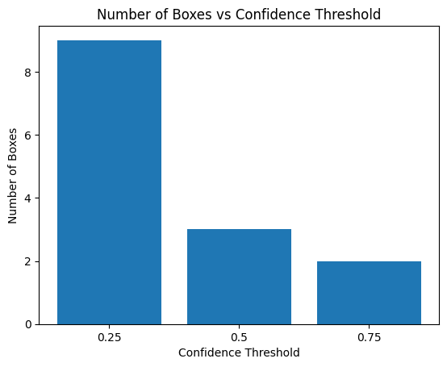

```
image 1/1 d:\deep learning\PR-3\data\images\messi5.jpg: 416x640 7 persons, 1 sports ball, 43.6ms
Speed: 970.8ms preprocess, 43.6ms inference, 3.3ms postprocess per image at shape (1, 3, 416, 640)
IoU: 0.3 -> Boxes kept: 8

image 1/1 d:\deep learning\PR-3\data\images\messi5.jpg: 416x640 7 persons, 1 sports ball, 43.8ms
Speed: 3.1ms preprocess, 43.8ms inference, 2.2ms postprocess per image at shape (1, 3, 416, 640)
IoU: 0.5 -> Boxes kept: 8

image 1/1 d:\deep learning\PR-3\data\images\messi5.jpg: 416x640 8 persons, 1 sports ball, 40.7ms
Speed: 2.9ms preprocess, 40.7ms inference, 2.7ms postprocess per image at shape (1, 3, 416, 640)
IoU: 0.7 -> Boxes kept: 9
```

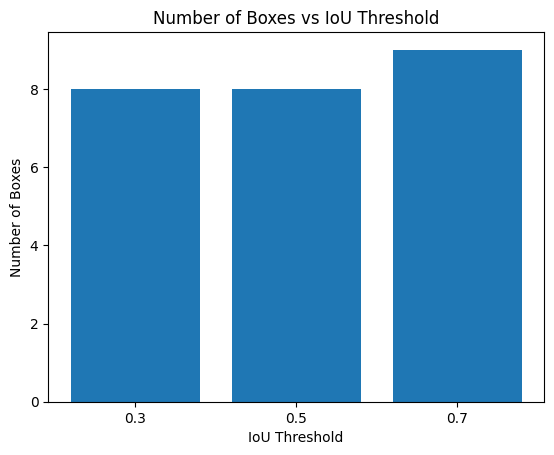

```
image 1/1 d:\deep learning\PR-3\data\images\messi5.jpg: 416x640 27 persons, 1 sports ball, 43.7ms
Speed: 110.1ms preprocess, 43.7ms inference, 4.0ms postprocess per image at shape (1, 3, 416, 640)

image 1/1 d:\deep learning\PR-3\data\images\messi5.jpg: 416x640 17 persons, 1 sports ball, 38.6ms
Speed: 3.7ms preprocess, 38.6ms inference, 1.8ms postprocess per image at shape (1, 3, 416, 640)
```

[figure not shown]

### 4.4 Per-class detection summary

```
image 1/1 d:\deep learning\PR-3\data\images\messi5.jpg: 416x640 8 persons, 1 sports ball, 43.6ms
Speed: 972.4ms preprocess, 43.6ms inference, 2.2ms postprocess per image at shape (1, 3, 416, 640)

image 1/1 d:\deep learning\PR-3\data\images\home.jpg: 480x640 7 kites, 51.3ms
Speed: 4.7ms preprocess, 51.3ms inference, 2.1ms postprocess per image at shape (1, 3, 480, 640)

image 1/1 d:\deep learning\PR-3\data\images\leuvenA.jpg: 480x640 1 clock, 43.0ms
Speed: 3.9ms preprocess, 43.0ms inference, 2.0ms postprocess per image at shape (1, 3, 480, 640)
{'sports ball': 1, 'person': 8, 'kite': 7, 'clock': 1}
```

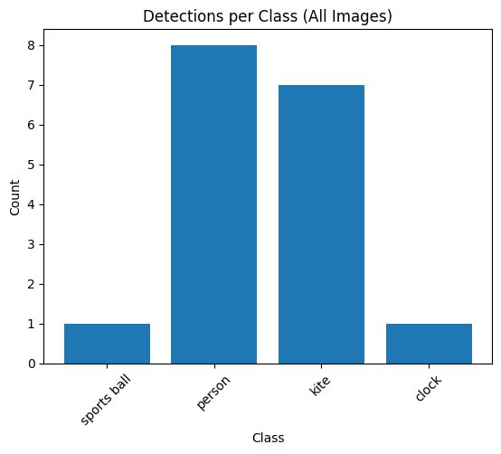

### 4.5 Why YOLO generalises

YOLO uses a single-stage, grid-based design: the input image is divided into a grid, and each grid cell directly predicts bounding boxes and class probabilities in one forward pass through the network — unlike older two-stage detectors that first propose regions and then classify them separately. This is followed by Non-Max Suppression (NMS), which removes duplicate overlapping boxes for the same object, keeping only the highest-confidence one per detection.

The 'nano' (n) variant used here is the smallest and fastest YOLOv8 model, trading some accuracy for speed and low resource use — ideal for real-time applications on modest hardware. Larger variants (s/m/l/x) are progressively more accurate but slower and heavier, better suited to offline processing or when accuracy matters more than speed.

A single pretrained model can detect all 80 COCO classes without any per-class hand-tuning because it was trained once, end-to-end, on a dataset already labeled with all 80 categories — the network learns shared, general visual features (edges, shapes, textures) in its early layers, and only the final layers specialize into distinguishing between the specific classes.

## Task 5: Integrated Pipeline & Final Comparison

### 5.1 Build the unified pipeline

### 5.2 Morphological pre-cleaning

```
0: 480x640 (no detections), 50.6ms
Speed: 280.3ms preprocess, 50.6ms inference, 1.3ms postprocess per image at shape (1, 3, 480, 640)

0: 480x640 1 bird, 3 kites, 48.8ms
Speed: 4.5ms preprocess, 48.8ms inference, 1.6ms postprocess per image at shape (1, 3, 480, 640)
Boxes detected (noisy): 0
Boxes detected (cleaned): 4
```

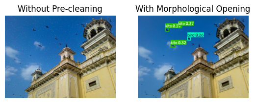

### 5.3 FPS benchmarking

```
Face detection FPS: 27.629554708943015
YOLO FPS: 28.003075441520544
Combined FPS: 27.656543549239192
```

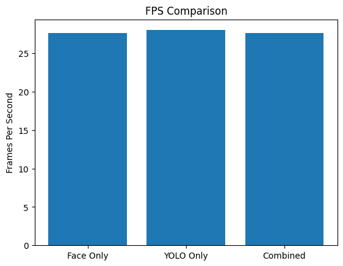

### 5.4 Final results comparison table

| Technique | Type | What It Detects | Lighting Robustness | Approx. FPS | Best Use Case |
| --- | --- | --- | --- | --- | --- |
| Morphology (erode/dilate/open/close) | Classical | Noise/shape cleanup in binary masks | Low (depends on threshold) | Very High (>100) | Pre-cleaning masks before detection |
| Bitwise Ops & Histograms | Classical | Masking, brightness/contrast diagnostics | Low-Medium | Very High (>100) | ROI extraction, exposure diagnostics |
| YuNet Face Detection | Deep Learning | Faces + 5 landmarks | High | Medium (varies by hardware) | Face-focused apps (attendance, blur/privacy) |
| YOLOv8 (nano) | Deep Learning | 80 COCO object classes | High | Medium (varies by hardware) | General object detection, surveillance |

### 5.5 Reflection

For a real-time monitoring use case, the best accuracy-to-compute trade-off in this pipeline is a light morphological opening (cheap, near-zero compute cost) combined with YuNet at a moderate score_threshold (around 0.7) for face detection, paired with YOLOv8-nano for general object detection. This combination keeps the combined FPS high enough for real-time use while still catching most real faces and objects.

If deploying on a low-power edge device, I would keep yolov8n (the smallest variant) and possibly raise the YuNet score_threshold slightly to reduce false positives, since compute is the limiting factor there. If deploying on a cloud server with more compute available, I would swap to yolov8s or yolov8m for higher accuracy, since FPS headroom is less of a constraint and detection quality becomes the priority instead.